# Homework_4

Graphing Descriptive Stats - ATP PEW

Lenna Garibian  
March 2022

Q19 - Pivot Longer; new dataframe “Leadership” where Confidence_in_world_leaders is new column name

```
  Confidence_in_world_leaders               Level Freq
1  Chinese_Jinping_Confidence A lot of confidence   29
2    French_Macron_Confidence A lot of confidence  259
3    German_Merkel_Confidence A lot of confidence  592
4    Russian_Putin_Confidence A lot of confidence   38
5         US_Biden_Confidence A lot of confidence  859
6  Chinese_Jinping_Confidence     Some confidence  296
```

Calculate percentages

```r
Leadership <- Leadership %>%

  group_by(`Confidence_in_world_leaders`, Level) %>%
  summarise(Freq = n()) %>%

  mutate(percentage = formattable::percent(Freq / sum(Freq)))
head(Leadership)
```

```
# A tibble: 6 × 4
# Groups:   Confidence_in_world_leaders [2]
  Confidence_in_world_leaders Level                    Freq percentage
  <chr>                       <fct>                   <int> <formttbl>
1 Chinese_Jinping_Confidence  A lot of confidence        29 1.12%
2 Chinese_Jinping_Confidence  Some confidence           296 11.40%
3 Chinese_Jinping_Confidence  Not too much confidence  1043 40.18%
4 Chinese_Jinping_Confidence  No confidence at all     1170 45.07%
5 Chinese_Jinping_Confidence  Refused                    58 2.23%
6 French_Macron_Confidence    A lot of confidence       259 9.98%
```

There may be a different way to calculate these percentages. Need to pull out the “Refused” responses eventually.

# Graph Leadership

Shows confidence Americans have in world leaders

```r
Leadership <- Leadership %>%
  select(Confidence_in_world_leaders, Level, percentage)
head(Leadership)
```

```
# A tibble: 6 × 3
# Groups:   Confidence_in_world_leaders [2]
  Confidence_in_world_leaders Level                   percentage
  <chr>                       <fct>                   <formttbl>
1 Chinese_Jinping_Confidence  A lot of confidence     1.12%
2 Chinese_Jinping_Confidence  Some confidence         11.40%
3 Chinese_Jinping_Confidence  Not too much confidence 40.18%
4 Chinese_Jinping_Confidence  No confidence at all    45.07%
5 Chinese_Jinping_Confidence  Refused                 2.23%
6 French_Macron_Confidence    A lot of confidence     9.98%
```

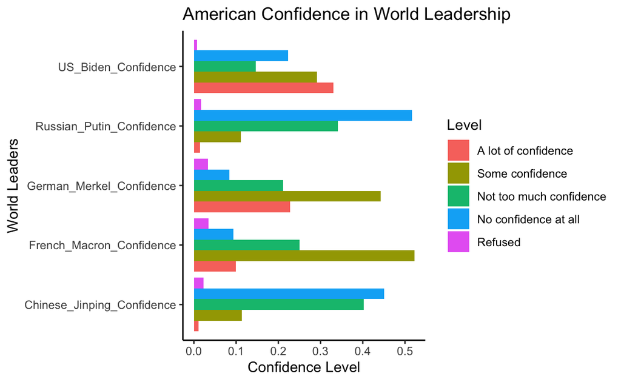

```r
ggplot(Leadership, aes(x=percentage, y=Confidence_in_world_leaders, fill=Level))+
geom_bar(stat = "identity", position = position_dodge())+

  labs(x="Confidence Level", y="World Leaders",
       title="American Confidence in World Leadership")+
  theme_classic()
```

## Graph Leadership Confidence by Education Level

Here, we take a look at American’s confidence in world leaders by their education level (F_EDUCAT).

```r
education <- atp_selected %>%
  select(US_Biden_Confidence, Chinese_Jinping_Confidence, Russian_Putin_Confidence,
         German_Merkel_Confidence, French_Macron_Confidence, F_EDUCCAT)

education <- pivot_longer(education, cols = c(US_Biden_Confidence, Chinese_Jinping_Confidence,
                                              Russian_Putin_Confidence, German_Merkel_Confidence,
                                              French_Macron_Confidence),
                          names_to = "confidence_in_world_leaders", values_to = "level")
```

```r
Leadership_conf_education <- education %>%
  group_by(confidence_in_world_leaders, F_EDUCCAT, level) %>%
  summarise(n())
```

```r
Leadership_conf_ed_summary<- education %>%
  filter(level %in%  c("A lot of confidence","Some confidence")) %>%

  group_by(confidence_in_world_leaders, F_EDUCCAT, level) %>%
  summarise(freq = n())
```

```r
Leadership_conf_ed_summary<- education %>%
  filter(level %in%  c("A lot of confidence","Some confidence")) %>%
   filter(F_EDUCCAT %in%  c("College graduate+","Some College", "H.S. graduate or less")) %>%
    group_by(confidence_in_world_leaders, F_EDUCCAT, level) %>%
  summarise(freq = n())
```

```r
Leadership_conf_ed_summary <- Leadership_conf_ed_summary %>%
  pivot_wider(names_from = "level", values_from = "freq")
Leadership_conf_ed_summary$Confidence<- Leadership_conf_ed_summary$`A lot of confidence`+
  Leadership_conf_ed_summary$`Some confidence`
```

```r
Leadership_conf_ed_summary <- Leadership_conf_ed_summary %>%
  select(-c(`A lot of confidence`, `Some confidence`))
```

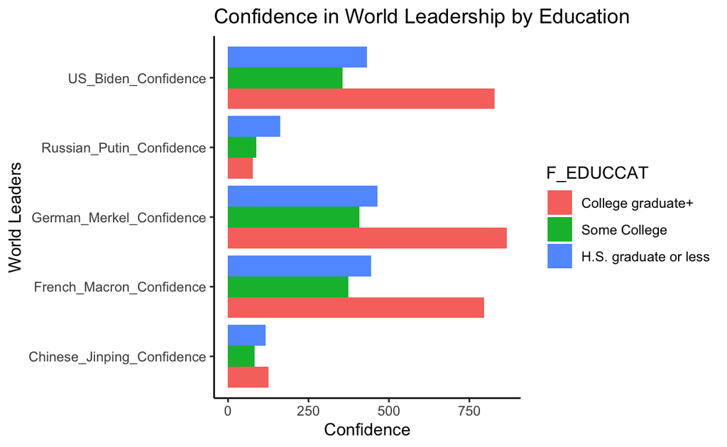

```r
ggplot(Leadership_conf_ed_summary, aes(x=confidence_in_world_leaders, y = Confidence, fill = F_EDUCCAT)) +
  geom_histogram(stat = "identity", position = position_dodge())+

  labs(x="World Leaders", y="Confidence", title="Confidence in World Leadership by Education")+
  coord_flip() +
  theme_classic()
```

## Graph Intl_Cooperation by Political Orientation:

Question 35

```r
US_cooperation_polit_lean <- atp_selected %>%
  select(Intl_Collaboration, F_PARTYSUMIDEO) %>%

  filter(Intl_Collaboration %in% c("MANY of the problems facing our country can be solved by working with other countries","FEW of the problems facing our country can be solved by working with other countries")) %>%
  group_by(`Intl_Collaboration`, F_PARTYSUMIDEO)%>%
summarise(freq = n()) %>%
    mutate(percentage = formattable::percent(freq / sum(freq)))
head(US_cooperation_polit_lean)
```

```
# A tibble: 6 × 4
# Groups:   Intl_Collaboration [2]
  Intl_Collaboration                   F_PARTYSUMIDEO  freq percentage
  <fct>                                <fct>          <int> <formttbl>
1 MANY of the problems facing our cou… Conservative …   188 13.19%
2 MANY of the problems facing our cou… Moderate/Libe…   156 10.95%
3 MANY of the problems facing our cou… Moderate/Cons…   483 33.89%
4 MANY of the problems facing our cou… Liberal Dem/L…   543 38.11%
5 MANY of the problems facing our cou… Refused eithe…    55 3.86%
6 FEW of the problems facing our coun… Conservative …   501 43.95%
```

[figure not shown]

```r
ggplot(US_cooperation_polit_lean, aes(x=Intl_Collaboration, y=percentage, fill=F_PARTYSUMIDEO))+
  geom_bar(stat = "identity", position = position_dodge())+
  labs(x="Collaborative Approach", y="Level", title = "American interest in intl. collaboration to solve world problems, by Polit. Party")+
  theme_classic()
```

Need to label legend, clean up x axis, pull out refused, and rethink variables.

## Comparing one variable based on responses to another:

Question 33 and 35;the proportion of people who rate a FX_Policy-goal at top priority (Q33), based on how they answered Intl-Collaboration (Q35)

```r
intl <- atp_selected %>%
select(c(9:19))

intl <- pivot_longer(intl, cols = c(Reduce_WeaponsMD,American_Jobs,Strengthen_UN,
                                    Reduce_USMil_Overseas, Limit_Russia_Power, Promote_Democracy_Overseas,
                                    Reduce_Illegal_Immigr, Limit_China_Power, Maintain_USMil_Advantage,
                                    Global_Climate_Change), names_to = "FX_Policy-goals", values_to ="Level") %>%             group_by(`FX_Policy-goals`,`Intl_Collaboration`) %>%
  filter(Intl_Collaboration %in% c("MANY of the problems facing our country can be solved by working with other countries","FEW of the problems facing our country can be solved by working with other countries")) %>%
summarise(freq = n()) %>%
    mutate(percentage = formattable::percent(freq / sum(freq)))
head(intl)
```

```
# A tibble: 6 × 4
# Groups:   FX_Policy-goals [3]
  `FX_Policy-goals`     Intl_Collaboration             freq percentage
  <chr>                 <fct>                         <int> <formttbl>
1 American_Jobs         MANY of the problems facing …  1425 55.56%
2 American_Jobs         FEW of the problems facing o…  1140 44.44%
3 Global_Climate_Change MANY of the problems facing …  1425 55.56%
4 Global_Climate_Change FEW of the problems facing o…  1140 44.44%
5 Limit_China_Power     MANY of the problems facing …  1425 55.56%
6 Limit_China_Power     FEW of the problems facing o…  1140 44.44%
```

```r
dim(intl)
```

```
[1] 20  4
```

# Dumbbell Plot:

Data frame with 4 columns; 2 variables (FX Policy Goals, Intl_Collaboration) and 2 values columns (one count; other percentage).

On y axis, want to plot different foreign policy goals On x axis, want the the percentage based on their response to Intl_Cooperation (ppl responding “FEW” vs. “MANY”) On a horizontal line with both percentage connected on a continuum along the x axis.

I tried to 2 methods, neither are working.

Method 1

[figure not shown]

```r
intl %>%
  ggplot(aes(x=percentage, y=`FX_Policy-goals`, color=Intl_Collaboration))+
geom_point()
```

Method 2?

```r
intl<-intl %>%
  mutate(paired = rep(1:(n()/2),each = 2), Intl_Collaboration = factor(Intl_Collaboration))
```